# MATH4995_P1

## Imports and loading the data

```python
import os
import numpy as np
import pandas as pd
import matplotlib.pyplot as plt
import seaborn as sns
%matplotlib inline

# GPU not needed in this demo
#assert os.environ['COLAB_GPU'] #'Make sure to select GPU from Edit > Notebook settings > Hardware accelerator'

from google.colab import drive
drive.mount('/content/drive')

# load the appropriate directory on Google Drive
!rm -f data
!ln -s '/content/drive/My Drive/4-1' data
```

## I - Conduct data preprocessing

Here, we load the training dataset into memory, and convert any categorical values (e.g. 'Sex') into numerical values for future ease of computation.

```python
# read the csv file into a pandas dataframe
df_train = pd.read_csv('data/titanic/train.csv')
nrow, ncol = df_train.shape
print(f'Train dataset has {nrow} rows and {ncol} columns')

# convert 'Sex' category to numeric
df_train.Sex = (df_train.Sex=='male') * 1

df_train.head()
```

```
Train dataset has 891 rows and 12 columns
```

|  | PassengerId | Survived | Pclass | Name | Sex | Age | SibSp | Parch | Ticket | Fare | Cabin | Embarked |
| --- | --- | --- | --- | --- | --- | --- | --- | --- | --- | --- | --- | --- |
| 0 | 1 | 0 | 3 | Braund, Mr. Owen Harris | 1 | 22.0 | 1 | 0 | A/5 21171 | 7.2500 | NaN | S |
| 1 | 2 | 1 | 1 | Cumings, Mrs. John Bradley (Florence Briggs Th... | 0 | 38.0 | 1 | 0 | PC 17599 | 71.2833 | C85 | C |
| 2 | 3 | 1 | 3 | Heikkinen, Miss. Laina | 0 | 26.0 | 0 | 0 | STON/O2. 3101282 | 7.9250 | NaN | S |
| 3 | 4 | 1 | 1 | Futrelle, Mrs. Jacques Heath (Lily May Peel) | 0 | 35.0 | 1 | 0 | 113803 | 53.1000 | C123 | S |
| 4 | 5 | 0 | 3 | Allen, Mr. William Henry | 1 | 35.0 | 0 | 0 | 373450 | 8.0500 | NaN | S |

```python
# check missing values
df_train.isnull().sum()
```

```
PassengerId      0
Survived         0
Pclass           0
Name             0
Sex              0
Age            177
SibSp            0
Parch            0
Ticket           0
Fare             0
Cabin          687
Embarked         2
dtype: int64
```

```python
# There are a lot of NA values in the Cabin category. For those that we do know, design a new feature called 'Cabin' denoting which deck of the ship they were on.
df_train['Cabin'].fillna('X', inplace=True)
df_train['Deck'] = df_train['Cabin'].str[0]
df_train.groupby('Deck').Deck.agg(len)

# then turn Deck into dummy columns (indicator variables), one for each of A-G, T, X, then drop Deck
deck_dummies_train = pd.get_dummies(df_train['Deck'], drop_first=False, prefix='Deck')
df_train = pd.concat([df_train, deck_dummies_train], axis=1)
df_train.drop('Deck', axis=1, inplace=True)
```

```python
# use a nested split to split the string of a person's name into their title (Mr, Miss, Rev, etc)
df_train['Honorific'] = df_train['Name'].str.rsplit(', ', n=1, expand=True)[1].str.rsplit(".", n=1, expand=True)[0]
df_train.groupby('Honorific').Honorific.agg(len)
```

```
Honorific
Capt                          1
Col                           2
Don                           1
Dr                            7
Jonkheer                      1
Lady                          1
Major                         2
Master                       40
Miss                        182
Mlle                          2
Mme                           1
Mr                          517
Mrs                         124
Mrs. Martin (Elizabeth L      1
Ms                            1
Rev                           6
Sir                           1
the Countess                  1
Name: Honorific, dtype: int64
```

We will also group the honorifics Jonkheer (Netherlands), Countess, Lady, Sir, etc. into a single group to construct another new feature "Unique".

```python
married_honorifics = ['Mrs','Mme','Ms','Mrs. Martin (Elizabeth L']
not_unique_honorifics = married_honorifics + ['Mr','Miss']

honorific_mask = df_train['Honorific'].apply(lambda s: s in married_honorifics)
unique_mask = df_train['Honorific'].apply(lambda s: s not in not_unique_honorifics)

pd.options.mode.chained_assignment = None # prevents warning in "df_train['isMarried'][honorific_mask] = 1" line
df_train['isMarried'] = 0
df_train['isMarried'][honorific_mask] = 1

df_train['Unique'] = 0
df_train['Unique'][unique_mask] = 1
df_train
```

|  | PassengerId | Survived | Pclass | Name | Sex | Age | SibSp | Parch | Ticket | Fare | Cabin | Embarked | Deck_A | Deck_B | Deck_C | Deck_D | Deck_E | Deck_F | Deck_G | Deck_T | Deck_X | Honorific | isMarried | Unique |
| --- | --- | --- | --- | --- | --- | --- | --- | --- | --- | --- | --- | --- | --- | --- | --- | --- | --- | --- | --- | --- | --- | --- | --- | --- |
| 0 | 1 | 0 | 3 | Braund, Mr. Owen Harris | 1 | 22.0 | 1 | 0 | A/5 21171 | 7.2500 | X | S | 0 | 0 | 0 | 0 | 0 | 0 | 0 | 0 | 1 | Mr | 0 | 0 |
| 1 | 2 | 1 | 1 | Cumings, Mrs. John Bradley (Florence Briggs Th... | 0 | 38.0 | 1 | 0 | PC 17599 | 71.2833 | C85 | C | 0 | 0 | 1 | 0 | 0 | 0 | 0 | 0 | 0 | Mrs | 1 | 0 |
| 2 | 3 | 1 | 3 | Heikkinen, Miss. Laina | 0 | 26.0 | 0 | 0 | STON/O2. 3101282 | 7.9250 | X | S | 0 | 0 | 0 | 0 | 0 | 0 | 0 | 0 | 1 | Miss | 0 | 0 |
| 3 | 4 | 1 | 1 | Futrelle, Mrs. Jacques Heath (Lily May Peel) | 0 | 35.0 | 1 | 0 | 113803 | 53.1000 | C123 | S | 0 | 0 | 1 | 0 | 0 | 0 | 0 | 0 | 0 | Mrs | 1 | 0 |
| 4 | 5 | 0 | 3 | Allen, Mr. William Henry | 1 | 35.0 | 0 | 0 | 373450 | 8.0500 | X | S | 0 | 0 | 0 | 0 | 0 | 0 | 0 | 0 | 1 | Mr | 0 | 0 |
| ... | ... | ... | ... | ... | ... | ... | ... | ... | ... | ... | ... | ... | ... | ... | ... | ... | ... | ... | ... | ... | ... | ... | ... | ... |
| 886 | 887 | 0 | 2 | Montvila, Rev. Juozas | 1 | 27.0 | 0 | 0 | 211536 | 13.0000 | X | S | 0 | 0 | 0 | 0 | 0 | 0 | 0 | 0 | 1 | Rev | 0 | 1 |
| 887 | 888 | 1 | 1 | Graham, Miss. Margaret Edith | 0 | 19.0 | 0 | 0 | 112053 | 30.0000 | B42 | S | 0 | 1 | 0 | 0 | 0 | 0 | 0 | 0 | 0 | Miss | 0 | 0 |
| 888 | 889 | 0 | 3 | Johnston, Miss. Catherine Helen "Carrie" | 0 | NaN | 1 | 2 | W./C. 6607 | 23.4500 | X | S | 0 | 0 | 0 | 0 | 0 | 0 | 0 | 0 | 1 | Miss | 0 | 0 |
| 889 | 890 | 1 | 1 | Behr, Mr. Karl Howell | 1 | 26.0 | 0 | 0 | 111369 | 30.0000 | C148 | C | 0 | 0 | 1 | 0 | 0 | 0 | 0 | 0 | 0 | Mr | 0 | 0 |
| 890 | 891 | 0 | 3 | Dooley, Mr. Patrick | 1 | 32.0 | 0 | 0 | 370376 | 7.7500 | X | Q | 0 | 0 | 0 | 0 | 0 | 0 | 0 | 0 | 1 | Mr | 0 | 0 |

891 rows × 24 columns

```python
# We expect 'Class' and 'Embarked' to have contributed to fare price.
# As such, we print the passengers who have 'NA' in their 'Embarked' column to have price be a function of 'Embarked' and 'Class'
# As such, we conduct a groupby to see which group most resembles the fare prices paid by the passengers with missing 'Embarked' values
df_train.groupby(['Pclass','Embarked']).Fare.agg(np.median)
```

```
Pclass  Embarked
1       C           78.2667
        Q           90.0000
        S           52.0000
2       C           24.0000
        Q           12.3500
        S           13.5000
3       C            7.8958
        Q            7.7500
        S            8.0500
Name: Fare, dtype: float64
```

```python
df_train[df_train['Embarked'].isna()]
```

|  | PassengerId | Survived | Pclass | Name | Sex | Age | SibSp | Parch | Ticket | Fare | Cabin | Embarked | Deck_A | Deck_B | Deck_C | Deck_D | Deck_E | Deck_F | Deck_G | Deck_T | Deck_X | Honorific | isMarried | Unique |
| --- | --- | --- | --- | --- | --- | --- | --- | --- | --- | --- | --- | --- | --- | --- | --- | --- | --- | --- | --- | --- | --- | --- | --- | --- |
| 61 | 62 | 1 | 1 | Icard, Miss. Amelie | 0 | 38.0 | 0 | 0 | 113572 | 80.0 | B28 | NaN | 0 | 1 | 0 | 0 | 0 | 0 | 0 | 0 | 0 | Miss | 0 | 0 |
| 829 | 830 | 1 | 1 | Stone, Mrs. George Nelson (Martha Evelyn) | 0 | 62.0 | 0 | 0 | 113572 | 80.0 | B28 | NaN | 0 | 1 | 0 | 0 | 0 | 0 | 0 | 0 | 0 | Mrs | 1 | 0 |

```python
# We can see that the closest fare price to our two missing values is Pclass=1, Embarked=C. So we fill both our missing values with 'C'.
df_train['Embarked'].fillna('C', inplace=True)

embarked_map = {'C':0, 'Q':1, 'S':2, 'X':3}
df_train['Embarked'].replace(embarked_map, inplace=True)
# then turn them into dummy columns (indicator variables), one for each of "C", "Q" and "S"
embarked_dummies_train = pd.get_dummies(df_train['Embarked'], drop_first=False, prefix='Embarked')
df_train = pd.concat([df_train, embarked_dummies_train], axis=1)
df_train.drop('Embarked', axis=1, inplace=True)

# drop the features 'Ticket', 'Cabin', 'Name', 'Honorific', 'PassengerId' now that we have converted them to something more useful
df_train.drop(columns=['Honorific','Cabin','Name','Ticket', 'PassengerId'],inplace=True)

df_train
```

|  | Survived | Pclass | Sex | Age | SibSp | Parch | Fare | Deck_A | Deck_B | Deck_C | Deck_D | Deck_E | Deck_F | Deck_G | Deck_T | Deck_X | isMarried | Unique | Embarked_0 | Embarked_1 | Embarked_2 |
| --- | --- | --- | --- | --- | --- | --- | --- | --- | --- | --- | --- | --- | --- | --- | --- | --- | --- | --- | --- | --- | --- |
| 0 | 0 | 3 | 1 | 22.0 | 1 | 0 | 7.2500 | 0 | 0 | 0 | 0 | 0 | 0 | 0 | 0 | 1 | 0 | 0 | 0 | 0 | 1 |
| 1 | 1 | 1 | 0 | 38.0 | 1 | 0 | 71.2833 | 0 | 0 | 1 | 0 | 0 | 0 | 0 | 0 | 0 | 1 | 0 | 1 | 0 | 0 |
| 2 | 1 | 3 | 0 | 26.0 | 0 | 0 | 7.9250 | 0 | 0 | 0 | 0 | 0 | 0 | 0 | 0 | 1 | 0 | 0 | 0 | 0 | 1 |
| 3 | 1 | 1 | 0 | 35.0 | 1 | 0 | 53.1000 | 0 | 0 | 1 | 0 | 0 | 0 | 0 | 0 | 0 | 1 | 0 | 0 | 0 | 1 |
| 4 | 0 | 3 | 1 | 35.0 | 0 | 0 | 8.0500 | 0 | 0 | 0 | 0 | 0 | 0 | 0 | 0 | 1 | 0 | 0 | 0 | 0 | 1 |
| ... | ... | ... | ... | ... | ... | ... | ... | ... | ... | ... | ... | ... | ... | ... | ... | ... | ... | ... | ... | ... | ... |
| 886 | 0 | 2 | 1 | 27.0 | 0 | 0 | 13.0000 | 0 | 0 | 0 | 0 | 0 | 0 | 0 | 0 | 1 | 0 | 1 | 0 | 0 | 1 |
| 887 | 1 | 1 | 0 | 19.0 | 0 | 0 | 30.0000 | 0 | 1 | 0 | 0 | 0 | 0 | 0 | 0 | 0 | 0 | 0 | 0 | 0 | 1 |
| 888 | 0 | 3 | 0 | NaN | 1 | 2 | 23.4500 | 0 | 0 | 0 | 0 | 0 | 0 | 0 | 0 | 1 | 0 | 0 | 0 | 0 | 1 |
| 889 | 1 | 1 | 1 | 26.0 | 0 | 0 | 30.0000 | 0 | 0 | 1 | 0 | 0 | 0 | 0 | 0 | 0 | 0 | 0 | 1 | 0 | 0 |
| 890 | 0 | 3 | 1 | 32.0 | 0 | 0 | 7.7500 | 0 | 0 | 0 | 0 | 0 | 0 | 0 | 0 | 1 | 0 | 0 | 0 | 1 | 0 |

891 rows × 21 columns

```python
# Now we have to clean up 'NA' in ages
df_train['Age'].describe()
```

```
count    714.000000
mean      29.699118
std       14.526497
min        0.420000
25%       20.125000
50%       28.000000
75%       38.000000
max       80.000000
Name: Age, dtype: float64
```

```python
# There are 177 data points with missing ages, and 891 data points in total.
# If we just replaced each missing data point with the mean or median, let's see what happens
mean_replace_df = df_train.copy()
mean_replace_df['Age'].fillna(df_train['Age'].mean(), inplace=True)
mean_replace_df['Age'].describe()
```

```
count    891.000000
mean      29.699118
std       13.002015
min        0.420000
25%       22.000000
50%       29.699118
75%       35.000000
max       80.000000
Name: Age, dtype: float64
```

```python
median_replace_df = df_train.copy()
median_replace_df['Age'].fillna(df_train['Age'].median(), inplace=True)
median_replace_df['Age'].describe()
```

```
count    891.000000
mean      29.361582
std       13.019697
min        0.420000
25%       22.000000
50%       28.000000
75%       35.000000
max       80.000000
Name: Age, dtype: float64
```

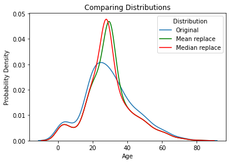

```python
# For better visualisation, let's plot the three distributions on the same graph using seaborn's 'kdeplot'
sns.kdeplot(df_train["Age"], label='Original')
sns.kdeplot(mean_replace_df["Age"], label='Mean replace', color='green')
sns.kdeplot(median_replace_df["Age"], label='Median replace', color='red')
plt.legend(title='Distribution', prop={'size': 10})
plt.title('Comparing Distributions')
plt.ylabel('Probability Density')
plt.xlabel('Age')
plt.show()
```

As seen in the above diagram, both the mean-replacement and median-replacement distributions appear to be heavily centered around the middle, which is inconsistent with the original distribution. Therefore, we must implement a way to fill in the missing values such that the resultant distribution is at least more similar to the original. The naive way would be to compute the original distribution function, then assign 'Age' values to missing values randomly according to that distribution. However, that fails to take into account the idea that the age distribution is at least correlated with some other factors. For instance, an individual with "Mrs" in their name you would not expect to be under 18, but the naive approach would not take that into consideration.

Therefore, we propose the approach of applying regression on each missing age value. Each missing Age value is defined to be the response variable $Y$ in some regression involving predictors drawn from other columns of the dataframe 'df_train', and we repeat this regression procedure until all the missing values are filled.

```python
!pip install impyute

from impyute.imputation.cs import mice
df_train_predictors = df_train.drop('Survived', axis=1) # not an inplace so it's fine
imputed = mice(df_train_predictors.values)
mice_ages = imputed[:, 2]

df_train['MiceAges'] = mice_ages
df_train['MiceAges'].describe()
```

```
count    891.000000
mean      29.567180
std       13.764413
min       -7.860656
25%       21.000000
50%       29.000000
75%       36.250000
max       80.000000
Name: MiceAges, dtype: float64
```

```python
# replace all negative values with 0
df_train['MiceAges'] = df_train['MiceAges'].mask(df_train['MiceAges'] < 0, 0)
df_train['MiceAges'].describe()
```

```
count    891.000000
mean      29.601815
std       13.679900
min        0.000000
25%       21.000000
50%       29.000000
75%       36.250000
max       80.000000
Name: MiceAges, dtype: float64
```

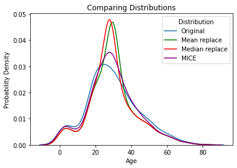

```python
sns.kdeplot(df_train["Age"], label='Original')
sns.kdeplot(mean_replace_df["Age"], label='Mean replace', color='green')
sns.kdeplot(median_replace_df["Age"], label='Median replace', color='red')
sns.kdeplot(df_train["MiceAges"], label='MICE', color='purple')
plt.legend(title='Distribution', prop={'size': 10})
plt.title('Comparing Distributions')
plt.ylabel('Probability Density')
plt.xlabel('Age')
plt.show()

# Keep the MICE ages, remove the old column 'Age'
df_train.drop("Age", axis=1, inplace=True)
```

Now we load the test dataset and apply the same data preprocessing methods we conducted on the training dataset:

1. Mapping 'Sex' to numeric
2. Converting Cabin to Deck, then converting Deck to indicator columns
3. Extracting Honorific from Name, then creating the features Unique and isMarried
4. Convert 'Embarked' to indicator columns
5. Clean missing values in Fare
6. Drop Cabin, Honorific, Name, Ticket
7. Clean missing values in Age

```python
# preprocess test dataset
df_test = pd.read_csv('data/titanic/test.csv')
df_test.isnull().sum()
```

```
PassengerId      0
Pclass           0
Name             0
Sex              0
Age             86
SibSp            0
Parch            0
Ticket           0
Fare             1
Cabin          327
Embarked         0
dtype: int64
```

```python
# Sex
df_test.Sex = (df_test.Sex=='male') * 1 # 'male'=>1, 'female'=>0

# Cabin => Deck => indicator columns
df_test['Cabin'].fillna('X', inplace=True)
df_test['Deck'] = df_test['Cabin'].str[0]
deck_dummies_test = pd.get_dummies(df_test['Deck'], drop_first=False, prefix='Deck')
df_test = pd.concat([df_test, deck_dummies_test], axis=1)
df_test.drop('Deck', axis=1, inplace=True)
df_test['Deck_T'] = 0 # missing Deck_T indicator column in test set, so add it back in

# Name => Honorific => isMarried, Unique
df_test['Honorific'] = df_test['Name'].str.rsplit(', ', n=1, expand=True)[1].str.rsplit(".", n=1, expand=True)[0]
df_test.groupby('Honorific').Honorific.agg(len)
honorific_mask = df_test['Honorific'].apply(lambda s: s in married_honorifics)
unique_mask = df_test['Honorific'].apply(lambda s: s not in not_unique_honorifics)

df_test['isMarried'] = 0
df_test['isMarried'][honorific_mask] = 1
df_test['Unique'] = 0
df_test['Unique'][unique_mask] = 1

# Embarked => indicator columns
#df_test['Embarked'].fillna('X', inplace=True) # No need since no NA values in Embarked in test set
df_test['Embarked'].replace(embarked_map, inplace=True)
embarked_dummies_test = pd.get_dummies(df_test['Embarked'], drop_first=False, prefix='Embarked')
df_test = pd.concat([df_test, embarked_dummies_test], axis=1)
df_test.drop('Embarked', axis=1, inplace=True)

# Fare
df_test['Fare'].fillna(df_test['Fare'].median(),inplace=True)
# don't remove passenger ID since we'll need it for submission
df_test.drop(columns=['Honorific', 'Cabin', 'Name', 'Ticket'], inplace=True)

# Age
imputed_test = mice(df_test.values)
mice_ages = imputed_test[:, 2]
df_test['MiceAges'] = mice_ages
df_test['MiceAges'] = df_test['MiceAges'].mask(df_test['MiceAges'] < 0, 0)
df_test.drop('Age', axis=1, inplace=True)
df_test['MiceAges'].describe()
```

```
count    418.000000
mean       0.636364
std        0.481622
min        0.000000
25%        0.000000
50%        1.000000
75%        1.000000
max        1.000000
Name: MiceAges, dtype: float64
```

```python
df_test
```

|  | PassengerId | Pclass | Sex | SibSp | Parch | Fare | Deck_A | Deck_B | Deck_C | Deck_D | Deck_E | Deck_F | Deck_G | Deck_X | Deck_T | isMarried | Unique | Embarked_0 | Embarked_1 | Embarked_2 | MiceAges |
| --- | --- | --- | --- | --- | --- | --- | --- | --- | --- | --- | --- | --- | --- | --- | --- | --- | --- | --- | --- | --- | --- |
| 0 | 892 | 3 | 1 | 0 | 0 | 7.8292 | 0 | 0 | 0 | 0 | 0 | 0 | 0 | 1 | 0 | 0 | 0 | 0 | 1 | 0 | 1.0 |
| 1 | 893 | 3 | 0 | 1 | 0 | 7.0000 | 0 | 0 | 0 | 0 | 0 | 0 | 0 | 1 | 0 | 1 | 0 | 0 | 0 | 1 | 0.0 |
| 2 | 894 | 2 | 1 | 0 | 0 | 9.6875 | 0 | 0 | 0 | 0 | 0 | 0 | 0 | 1 | 0 | 0 | 0 | 0 | 1 | 0 | 1.0 |
| 3 | 895 | 3 | 1 | 0 | 0 | 8.6625 | 0 | 0 | 0 | 0 | 0 | 0 | 0 | 1 | 0 | 0 | 0 | 0 | 0 | 1 | 1.0 |
| 4 | 896 | 3 | 0 | 1 | 1 | 12.2875 | 0 | 0 | 0 | 0 | 0 | 0 | 0 | 1 | 0 | 1 | 0 | 0 | 0 | 1 | 0.0 |
| ... | ... | ... | ... | ... | ... | ... | ... | ... | ... | ... | ... | ... | ... | ... | ... | ... | ... | ... | ... | ... | ... |
| 413 | 1305 | 3 | 1 | 0 | 0 | 8.0500 | 0 | 0 | 0 | 0 | 0 | 0 | 0 | 1 | 0 | 0 | 0 | 0 | 0 | 1 | 1.0 |
| 414 | 1306 | 1 | 0 | 0 | 0 | 108.9000 | 0 | 0 | 1 | 0 | 0 | 0 | 0 | 0 | 0 | 0 | 1 | 1 | 0 | 0 | 0.0 |
| 415 | 1307 | 3 | 1 | 0 | 0 | 7.2500 | 0 | 0 | 0 | 0 | 0 | 0 | 0 | 1 | 0 | 0 | 0 | 0 | 0 | 1 | 1.0 |
| 416 | 1308 | 3 | 1 | 0 | 0 | 8.0500 | 0 | 0 | 0 | 0 | 0 | 0 | 0 | 1 | 0 | 0 | 0 | 0 | 0 | 1 | 1.0 |
| 417 | 1309 | 3 | 1 | 1 | 1 | 22.3583 | 0 | 0 | 0 | 0 | 0 | 0 | 0 | 1 | 0 | 0 | 1 | 1 | 0 | 0 | 1.0 |

418 rows × 21 columns

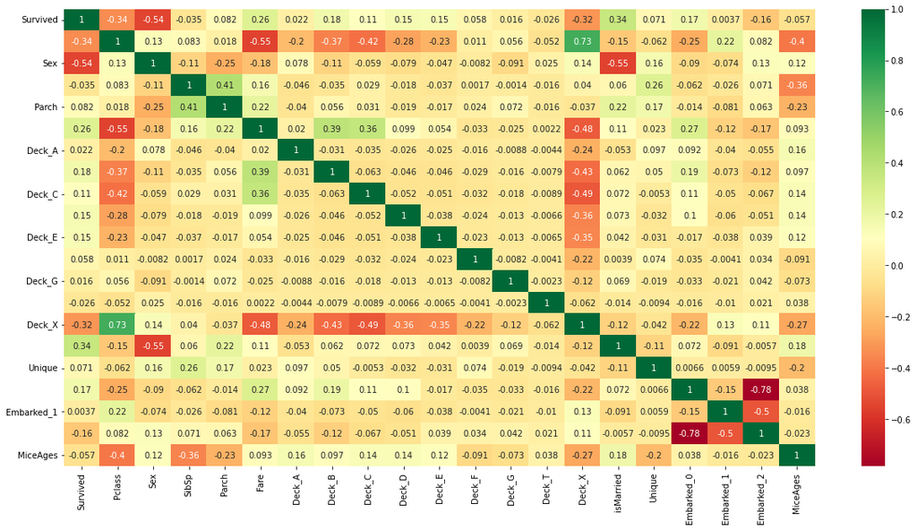

```python
sns.heatmap(df_train.corr(), annot=True, cmap='RdYlGn')
fig = plt.gcf()
fig.set_size_inches(20, 10)
plt.show()
```

From the correlation heatmap, we can see the largest absolute values of the correlations are between the indicator columns Embarked_0 and Embarked_2. This is because each passenger can only be embarking from exactly one of three possible points. The same can be said for the negative correlations between Deck_X and the other Deck indicator columns.

In fact, there is also a high correlation (0.73) between PClass and Deck_X, so to avoid collinearity, we should remove one of these features. Since Deck_X has a high negative correlation with the other Deck indicator columns, if we removed it, we would still be able to identify a passenger from Deck_X because all the other Deck indicator columns would have value 0 (so we are not losing any information.) Hence we shall remove Deck_X from both the training and test dataframes. (We will also do the same for Embarked_2 to reduce collinearity, since removing it is not a loss of information.)

We observe that there is a fairly strong (-0.54) negative correlation between Survived and Sex, and a weak positive correlation between Survived and isMarried as well as between Survived and Fare. There is also a strong negaitive correlation between Fare and Pclass which again makes sense. Therefore it makes sense to include the features 'Sex', 'isMarried', and either 'Pclass' or 'Fare' in our model.

The remaining correlations are mostly below 0.5, so we don't need to remove any more features at this stage.

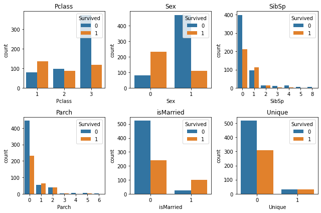

```python
# drop Deck_X, Embarked_2, Fare
df_train.drop(columns=['Deck_X','Embarked_2','Fare'],inplace=True)
df_test.drop(columns=['Deck_X','Embarked_2','Fare'],inplace=True)

# plot each feature of interest in a subplot
features_of_interest = ['Pclass', 'Sex', 'SibSp', 'Parch', 'isMarried', 'Unique']

n_rows = 2
n_cols = 3

fig, axs = plt.subplots(n_rows, n_cols, figsize=(n_cols*3, n_rows*3))

for r in range(0, n_rows):
    for c in range(0, n_cols):

        i = r * n_cols + c
        ax = axs[r][c]
        sns.countplot(df_train[features_of_interest[i]], hue=df_train['Survived'], ax=ax)
        ax.set_title(features_of_interest[i])
        ax.legend(title="Survived", loc='upper right')

plt.tight_layout()
```

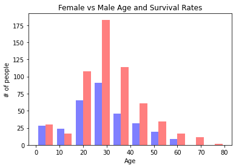

```python
female_ages = df_train[df_train["Sex"]==1]["MiceAges"]
male_ages = df_train[df_train["Sex"]==0]["MiceAges"]
plt.hist([male_ages, female_ages],
         color=['b','r'], alpha=0.5)
plt.title('Female vs Male Age and Survival Rates')
plt.ylabel('# of people')
plt.xlabel('Age')
plt.show()
```

```python
# save the labels separately
train_labels = df_train['Survived']
df_train.drop('Survived', axis=1, inplace=True)
```

## II - Using various models as prediction

We will try a variety of models here, including k-Nearest Neighbours, Logistic Regression and Random Forest. We ignore Decision Trees since Random Forest should cover that.

```python
# K-Nearest neighbours
from sklearn import metrics
from sklearn.neighbors import KNeighborsClassifier

# try various values for the hyperparameter K. Choose the one that produces the best accuracy score
k_range = range(1,30)
knn_train_scores = []
for k in k_range:
  knn_model = KNeighborsClassifier(n_neighbors=k)
  knn_model.fit(df_train, train_labels)
  knn_train_pred = knn_model.predict(df_train)
  knn_train_scores.append([k, metrics.accuracy_score(train_labels, knn_train_pred)])
knn_train_scores.sort(key=lambda x: x[1])
print("Best value of K: {} and corresponding accuracy: {}" .format(
    knn_train_scores[len(knn_train_scores)-1][0],
    knn_train_scores[len(knn_train_scores)-1][1]))
```

```
Best value of K: 1 and corresponding accuracy: 0.9450056116722784
```

```python
knn_train_scores
```

```
[[26, 0.7205387205387206],
 [28, 0.7261503928170595],
 [29, 0.7295173961840629],
 [27, 0.7328843995510662],
 [24, 0.7373737373737373],
 [25, 0.745230078563412],
 [22, 0.7497194163860831],
 [20, 0.7564534231200898],
 [23, 0.7586980920314254],
 [18, 0.7643097643097643],
 [21, 0.7665544332210998],
 [16, 0.7732884399551067],
 [19, 0.77665544332211],
 [17, 0.7777777777777778],
 [14, 0.7833894500561167],
 [12, 0.7856341189674523],
 [10, 0.7890011223344556],
 [8, 0.7901234567901234],
 [15, 0.7957351290684624],
 [11, 0.8013468013468014],
 [13, 0.8013468013468014],
 [9, 0.8080808080808081],
 [6, 0.8159371492704826],
 [7, 0.819304152637486],
 [4, 0.8417508417508418],
 [5, 0.8439955106621774],
 [2, 0.856341189674523],
 [3, 0.8754208754208754],
 [1, 0.9450056116722784]]
```

```python
from sklearn.model_selection import cross_val_score

knn_scores = cross_val_score(knn_model, df_train, train_labels, cv=10, scoring = "accuracy")
print("Scores:", knn_scores)
print("Mean:", knn_scores.mean())
print("Standard Deviation:", knn_scores.std())
```

```
Scores: [0.7        0.68539326 0.6741573  0.73033708 0.75280899 0.68539326
 0.73033708 0.69662921 0.79775281 0.64044944]
Mean: 0.7093258426966292
Standard Deviation: 0.04238815235616161
```

Although it may look like K-NN is a very good model with a 94.5% accuracy, note that K=1. This heavily implies that the k-NN model overfits to the training data, because when K=1 the probability of one sample is estimated ONLY on ONE OTHER sample, which by definition is very susceptible to noise, outliers, etc. As such we cannot assume this model's training accuracy to be indicative of its performance on the unknown test set. In fact, one common estimate of an 'optimal' value of K in a dataset with n points (in our case $n=891$) is $\sqrt{n}$ which is roughly 29.

When we observe the training accuracy score of the K-NN model at high values of K (23-29) we notice the accuracy score hovers around ~75%. The validation accuracy score is around 70.9% for the chosen value of K=29, which is slightly lower than the training accuracy score (as expected, since all models will overfit to the training dataset to a small extent.)

```python
# Logistic regression
from sklearn.linear_model import LogisticRegression
from sklearn.metrics import confusion_matrix

lr_model = LogisticRegression(penalty='l2', solver='liblinear')
lr_model.fit(df_train, train_labels)
lr_train_pred = lr_model.predict(df_train)
print("Logistic regression training accuracy score: {}" .format(metrics.accuracy_score(lr_train_pred, train_labels)))

# compute cross validation score
lr_scores = cross_val_score(lr_model, df_train, train_labels, cv=10, scoring = "accuracy")
print("Scores:", lr_scores)
print("Mean:", lr_scores.mean())
print("Standard Deviation:", lr_scores.std())
```

```
Logistic regression training accuracy score: 0.8294051627384961
Scores: [0.8        0.84269663 0.76404494 0.86516854 0.83146067 0.80898876
 0.84269663 0.82022472 0.85393258 0.82022472]
Mean: 0.8249438202247191
Standard Deviation: 0.027858824939400544
```

```python
# create random forest model and fit it to training data
from sklearn.ensemble import RandomForestClassifier
myRandomState = 9090
rf_model = RandomForestClassifier(n_estimators=150, max_depth=7, random_state=myRandomState)
rf_model.fit(df_train, train_labels)

rf_train_predict = rf_model.predict(df_train)
print("Random forest training accuracy score: {}".format(rf_model.score(df_train, train_labels)))
```

```
Random forest training accuracy score: 0.8843995510662177
```

```python
rf_scores = cross_val_score(rf_model, df_train, train_labels, cv=10, scoring = "accuracy")
print("Scores:", rf_scores)
print("Mean:", rf_scores.mean())
print("Standard Deviation:", rf_scores.std())

# Generate confusion matrix
y_prob2 = rf_model.predict_proba(df_train)
df_matrix = pd.DataFrame({'True label': train_labels,'Predicted label': y_prob2[:,1] > 0.5})
df_matrix.replace(to_replace={0: 'Didn\'t survive', 1:'Survived'}, inplace=True)
df_matrix.groupby(['Predicted label','True label']).size().unstack('True label')
```

```
Scores: [0.82222222 0.82022472 0.79775281 0.87640449 0.87640449 0.82022472
 0.84269663 0.7752809  0.86516854 0.85393258]
Mean: 0.8350312109862671
Standard Deviation: 0.03210932873121965
```

| True label Predicted label | Didn't survive | Survived |
| --- | --- | --- |
| Didn't survive | 527 | 81 |
| Survived | 22 | 261 |

From our 3 models: K-NN, Logistic Regression and Random Forest, it appears Random Forest has the best training accuracy score, and even has a higher mean 10-fold cross-validation score than both the K-NN and Logistic Regression models. As such, we attempt to further tune the Random Forest model.

```python
# show the importance of each feature in df_train in our initial random forest model
importances = pd.DataFrame({'feature': df_train.columns,
                            'importance': np.round(rf_model.feature_importances_, 3)})
importances = importances.sort_values('importance',ascending=False).set_index('feature')
importances
```

| feature | importance |
| --- | --- |
| Sex | 0.361 |
| MiceAges | 0.157 |
| Pclass | 0.142 |
| isMarried | 0.096 |
| SibSp | 0.060 |
| Parch | 0.043 |
| Embarked_0 | 0.027 |
| Unique | 0.024 |
| Deck_E | 0.022 |
| Deck_B | 0.018 |
| Deck_D | 0.016 |
| Embarked_1 | 0.015 |
| Deck_C | 0.010 |
| Deck_A | 0.003 |
| Deck_F | 0.003 |
| Deck_G | 0.002 |
| Deck_T | 0.000 |

```python
# As we can see from the above table, we can probably drop the features Deck T, G, D, C, F, and A since they're not that important to the random forest model and including them will cause the model to overfit to the test set.
# Embarked_1, Deck_B, Deck_E, Embarked_0, Unique, and Parch are a little more up in the air. To decide which to keep, we'll implement a modified form of backwards subset selection:
# remove the lowest-importance feature from df_train, and fit it to a random forest. Evaluate the new model's 10-fold cross validation score to estimate the test error, and save the score in an array.
# As described in the lectures, we'll locate the model with the highest cross-validation score and choose the best model to be the one whose cross validation score is within 1SD of the maximum cross validation score AND has the fewest features.
columns_to_drop = ['Deck_T','Deck_G','Deck_A','Deck_F','Deck_C','Deck_D','Embarked_1','Deck_E','Deck_B','Embarked_0','Unique','Parch']

rf_scores_array = []
rf_models_array = []

for i in range(0, len(columns_to_drop)):
  print("==================")
  df_train_refined = df_train.copy()
  # subset selection
  df_train_refined.drop(columns=columns_to_drop[:i+1], axis=1, inplace=True)
  rf_model_2 = RandomForestClassifier(n_estimators=150, max_depth=7, random_state=myRandomState)
  rf_model_2.fit(df_train_refined, train_labels)

  # save the model
  rf_models_array.append(rf_model_2)

  # training score
  rf_train_predict_2 = rf_model_2.predict(df_train_refined)
  print("Training score: {}" .format(rf_model_2.score(df_train_refined, train_labels)))

  # compute mean cross-validation score
  rf_scores_2 = cross_val_score(rf_model_2, df_train_refined, train_labels, cv=10, scoring = "accuracy")
  print("Scores:", rf_scores_2)
  print("Mean:", rf_scores_2.mean())
  print("Standard Deviation:", rf_scores_2.std())
  # store the index i, the mean CV score, and the SD of the CV score
  rf_scores_array.append([i, rf_scores_2.mean(), rf_scores_2.std()])
```

```
==================
Training score: 0.8832772166105499
Scores: [0.81111111 0.84269663 0.7752809  0.87640449 0.85393258 0.82022472
 0.84269663 0.7752809  0.85393258 0.85393258]
Mean: 0.8305493133583022
Standard Deviation: 0.03260641117801103
==================
Training score: 0.8821548821548821
Scores: [0.83333333 0.82022472 0.76404494 0.87640449 0.91011236 0.83146067
 0.85393258 0.7752809  0.86516854 0.85393258]
Mean: 0.8383895131086142
Standard Deviation: 0.04207486369292761
==================
Training score: 0.8810325476992144
Scores: [0.82222222 0.80898876 0.76404494 0.87640449 0.87640449 0.80898876
 0.83146067 0.7752809  0.85393258 0.86516854]
Mean: 0.8282896379525594
Standard Deviation: 0.037916904534562035
==================
Training score: 0.8832772166105499
Scores: [0.83333333 0.80898876 0.76404494 0.88764045 0.88764045 0.83146067
 0.84269663 0.7752809  0.86516854 0.84269663]
Mean: 0.8338951310861422
Standard Deviation: 0.03981372060746372
==================
Training score: 0.8866442199775533
Scores: [0.82222222 0.83146067 0.7752809  0.88764045 0.88764045 0.82022472
 0.82022472 0.78651685 0.83146067 0.85393258]
Mean: 0.8316604244694131
Standard Deviation: 0.03511535068408205
==================
Training score: 0.8843995510662177
Scores: [0.82222222 0.82022472 0.75280899 0.88764045 0.91011236 0.83146067
 0.83146067 0.7752809  0.86516854 0.84269663]
Mean: 0.8339076154806492
Standard Deviation: 0.04483157018625607
==================
Training score: 0.8765432098765432
Scores: [0.8        0.83146067 0.75280899 0.88764045 0.86516854 0.82022472
 0.84269663 0.80898876 0.86516854 0.84269663]
```

[output cut: 17 more lines]

```
 0.83146067 0.79775281 0.87640449 0.84269663]
Mean: 0.8294756554307116
Standard Deviation: 0.044512301086648484
==================
Training score: 0.8821548821548821
Scores: [0.75555556 0.85393258 0.75280899 0.88764045 0.86516854 0.80898876
 0.84269663 0.79775281 0.87640449 0.86516854]
Mean: 0.8306117353308364
Standard Deviation: 0.04654187630265947
==================
Training score: 0.8866442199775533
Scores: [0.77777778 0.80898876 0.76404494 0.86516854 0.86516854 0.83146067
 0.84269663 0.78651685 0.85393258 0.84269663]
Mean: 0.8238451935081148
Standard Deviation: 0.0352159520536824
```

```python
rf_scores_array.sort(key=lambda x: x[1])
print(rf_scores_array[len(rf_scores_array)-1])
```

```
[1, 0.8383895131086142, 0.04207486369292761]
```

```python
# retrieve the correct random forest model
modelnumber = rf_scores_array[len(rf_scores_array)-1][0]
rf_model_2 = rf_models_array[modelnumber]

df_train_refined = df_train.copy()
df_train_refined.drop(columns=columns_to_drop[:modelnumber+1], axis=1, inplace=True)

# show the confusion matrix
y_prob2 = rf_model_2.predict_proba(df_train_refined)
df_matrix = pd.DataFrame({'True label': train_labels,'Predicted label': y_prob2[:,1] > 0.5})
df_matrix.replace(to_replace={0: 'Didn\'t survive', 1:'Survived'}, inplace=True)
df_matrix.groupby(['Predicted label','True label']).size().unstack('True label')
```

| True label Predicted label | Didn't survive | Survived |
| --- | --- | --- |
| Didn't survive | 525 | 81 |
| Survived | 24 | 261 |

```python
test_passenger_ids = df_test['PassengerId']
df_test.drop('PassengerId', axis=1, inplace=True)
```

```python
# predict on test set and save in csv
rf_predictions = rf_model.predict(df_test)
rf_output = pd.DataFrame({'PassengerId': test_passenger_ids, 'Survived': rf_predictions})
rf_output.to_csv('data/20589533_rf.csv', index=False)

print("Random forest model output generated!")
```

```
Random forest model output generated!
```

## Future analysis

```python
from sklearn.ensemble import AdaBoostClassifier

columns_to_drop = ['Deck_T','Deck_G','Deck_A','Deck_F','Deck_C','Deck_D','Embarked_1','Deck_E','Deck_B','Embarked_0','Unique','Parch']

ab_randomState = 666
ab_scores_array = []

for i in range(0, len(columns_to_drop)):
  print("==================")
  df_train_refined = df_train.copy()
  # backward selection
  df_train_refined.drop(columns=columns_to_drop[:i+1], axis=1, inplace=True)
  ab_model_2 = AdaBoostClassifier(n_estimators=30, learning_rate=0.7, random_state=ab_randomState)
  ab_model_2.fit(df_train_refined, train_labels)

  # training score
  ab_train_predict_2 = ab_model_2.predict(df_train_refined)
  print("Training score: {}" .format(ab_model_2.score(df_train_refined, train_labels)))

  # compute mean cross-validation score
  ab_scores_2 = cross_val_score(ab_model_2, df_train_refined, train_labels, cv=10, scoring = "accuracy")
  print("Scores:", ab_scores_2)
  print("Mean:", ab_scores_2.mean())
  print("Standard Deviation:", ab_scores_2.std())
  # store the index i, the mean CV score, and the SD of the CV score
  ab_scores_array.append([i, ab_scores_2.mean(), ab_scores_2.std()])

print("********************")
ab_scores_array.sort(key=lambda x: x[1])
modelnumber = ab_scores_array[len(ab_scores_array)-1][0]
ab_highest_mean_score = ab_scores_array[len(ab_scores_array)-1][1]
ab_highest_sd_score = ab_scores_array[len(ab_scores_array)-1][2]

ab_scores_array = [x for x in ab_scores_array if x[1] >= ab_highest_mean_score-ab_highest_sd_score]
for i in ab_scores_array:
  print(i) # prints all models whose 10-fold mean CV score is within 1SD of the maximum
```

```
==================
Training score: 0.8271604938271605
Scores: [0.8        0.80898876 0.76404494 0.84269663 0.78651685 0.82022472
 0.83146067 0.82022472 0.86516854 0.79775281]
Mean: 0.8137078651685392
Standard Deviation: 0.027493902182852244
==================
Training score: 0.8271604938271605
Scores: [0.78888889 0.80898876 0.76404494 0.84269663 0.80898876 0.82022472
 0.83146067 0.82022472 0.86516854 0.79775281]
Mean: 0.8148439450686642
Standard Deviation: 0.026939255068542053
==================
Training score: 0.8271604938271605
Scores: [0.78888889 0.80898876 0.76404494 0.84269663 0.80898876 0.82022472
 0.83146067 0.82022472 0.86516854 0.79775281]
Mean: 0.8148439450686642
Standard Deviation: 0.026939255068542053
==================
Training score: 0.8271604938271605
Scores: [0.78888889 0.80898876 0.76404494 0.84269663 0.80898876 0.82022472
 0.83146067 0.82022472 0.86516854 0.79775281]
Mean: 0.8148439450686642
Standard Deviation: 0.026939255068542053
==================
Training score: 0.8271604938271605
Scores: [0.78888889 0.80898876 0.76404494 0.84269663 0.80898876 0.82022472
 0.83146067 0.82022472 0.86516854 0.79775281]
Mean: 0.8148439450686642
Standard Deviation: 0.026939255068542053
==================
Training score: 0.8305274971941639
Scores: [0.77777778 0.82022472 0.76404494 0.86516854 0.80898876 0.80898876
 0.83146067 0.80898876 0.88764045 0.79775281]
Mean: 0.817103620474407
Standard Deviation: 0.03526371871118026
==================
Training score: 0.8305274971941639
Scores: [0.77777778 0.82022472 0.76404494 0.86516854 0.80898876 0.80898876
 0.83146067 0.82022472 0.88764045 0.79775281]
```

[output cut: 29 more lines]

```
 0.82022472 0.76404494 0.83146067 0.82022472]
Mean: 0.8092009987515606
Standard Deviation: 0.025629829485651907
[11, 0.8092009987515606, 0.025629829485651907]
[7, 0.8125842696629213, 0.026970037193128082]
[0, 0.8137078651685392, 0.027493902182852244]
[9, 0.8137078651685392, 0.02655966834940621]
[8, 0.8148314606741573, 0.027044829453178206]
[1, 0.8148439450686642, 0.026939255068542053]
[2, 0.8148439450686642, 0.026939255068542053]
[3, 0.8148439450686642, 0.026939255068542053]
[4, 0.8148439450686642, 0.026939255068542053]
[10, 0.8159550561797753, 0.027475528816604255]
[5, 0.817103620474407, 0.03526371871118026]
[6, 0.8182272159800249, 0.035166126125259926]
```

From there, we choose the simplest model. Notice that all the models have 10-fold mean CV score within 1SD of the maximum, so we choose the simplest model of dropping all columns in 'columns_to_drop'.

```python
modelnumber = len(columns_to_drop)

# grid search for best hyperparameters
# we don't want to choose values that are too large - the Titanic dataset is already too small and very prone to overfitting!
# learning rates < 1
# We omitted it here, but I had previously tried ab_n_estimators = [50, 100, 150, 200, 250] and the training accuracy score still hovered around 85%
ab_learning_rates = [0.04, 0.1, 0.2, 0.4, 0.7]
ab_n_estimators = [10, 20, 30, 40, 50]

ab_scores_array = []
df_train_refined = df_train.copy().drop(columns=columns_to_drop[:modelnumber+1], axis=1)

for i in range(len(ab_learning_rates)):
  for j in range(len(ab_n_estimators)):
    ab_model = AdaBoostClassifier(base_estimator=None, # use a single DecisionTreeClassifier as base estimator
                                learning_rate=ab_learning_rates[i],
                                n_estimators=ab_n_estimators[j],
                                random_state=ab_randomState)
    ab_model.fit(df_train_refined, train_labels)

    ab_train_predict = ab_model.predict(df_train_refined)
    print("Adaboost (lr={}, n_estimators={}) training accuracy score: {}".format(ab_learning_rates[i], ab_n_estimators[j], ab_model.score(df_train_refined, train_labels)))

    ab_scores = cross_val_score(ab_model, df_train_refined, train_labels, cv=10, scoring = "accuracy")
    print("Mean 10-fold CV score: {}, SD: {}" .format(ab_scores.mean(), ab_scores.std()))
    # store the indices i, j, the mean CV score, and the SD of the CV score
    ab_scores_array.append([i, j, ab_scores.mean(), ab_scores.std()])

  print("===============")

print("********************")
ab_scores_array.sort(key=lambda x: x[2])
ab_highest_score_i = ab_scores_array[len(ab_scores_array)-1][0]
ab_highest_score_j = ab_scores_array[len(ab_scores_array)-1][1]
ab_highest_mean_score = ab_scores_array[len(ab_scores_array)-1][2]
ab_highest_sd_score = ab_scores_array[len(ab_scores_array)-1][3]
print("Hyperparameters ({}, {}) that produced highest mean 10-fold CV score: {}" .format(ab_learning_rates[ab_highest_score_i],
                                                                                         ab_n_estimators[ab_highest_score_j],
                                                                                         ab_highest_mean_score))

ab_scores_array = [x for x in ab_scores_array if x[2] >= ab_highest_mean_score-ab_highest_sd_score]
for i in ab_scores_array:
  print(i)
```

```
Adaboost (lr=0.04, n_estimators=10) training accuracy score: 0.7867564534231201
Mean 10-fold CV score: 0.786729088639201, SD: 0.028599350013463757
Adaboost (lr=0.04, n_estimators=20) training accuracy score: 0.7867564534231201
Mean 10-fold CV score: 0.786729088639201, SD: 0.028599350013463757
Adaboost (lr=0.04, n_estimators=30) training accuracy score: 0.7867564534231201
Mean 10-fold CV score: 0.786729088639201, SD: 0.028599350013463757
Adaboost (lr=0.04, n_estimators=40) training accuracy score: 0.7867564534231201
Mean 10-fold CV score: 0.786729088639201, SD: 0.028599350013463757
Adaboost (lr=0.04, n_estimators=50) training accuracy score: 0.7867564534231201
Mean 10-fold CV score: 0.786729088639201, SD: 0.028599350013463757
===============
Adaboost (lr=0.1, n_estimators=10) training accuracy score: 0.7867564534231201
Mean 10-fold CV score: 0.786729088639201, SD: 0.028599350013463757
Adaboost (lr=0.1, n_estimators=20) training accuracy score: 0.7867564534231201
Mean 10-fold CV score: 0.786729088639201, SD: 0.028599350013463757
Adaboost (lr=0.1, n_estimators=30) training accuracy score: 0.7867564534231201
Mean 10-fold CV score: 0.787852684144819, SD: 0.027898197371873965
Adaboost (lr=0.1, n_estimators=40) training accuracy score: 0.7934904601571269
Mean 10-fold CV score: 0.7934706616729088, SD: 0.027283018261713754
Adaboost (lr=0.1, n_estimators=50) training accuracy score: 0.7957351290684624
Mean 10-fold CV score: 0.7945942571785268, SD: 0.027204756072482808
===============
Adaboost (lr=0.2, n_estimators=10) training accuracy score: 0.7867564534231201
Mean 10-fold CV score: 0.786729088639201, SD: 0.028599350013463757
Adaboost (lr=0.2, n_estimators=20) training accuracy score: 0.792368125701459
Mean 10-fold CV score: 0.7934706616729088, SD: 0.027283018261713754
Adaboost (lr=0.2, n_estimators=30) training accuracy score: 0.8069584736251403
Mean 10-fold CV score: 0.7990761548064919, SD: 0.02743138252768863
Adaboost (lr=0.2, n_estimators=40) training accuracy score: 0.8069584736251403
Mean 10-fold CV score: 0.8046941323345818, SD: 0.031566079889634946
Adaboost (lr=0.2, n_estimators=50) training accuracy score: 0.8080808080808081
Mean 10-fold CV score: 0.8058177278401997, SD: 0.03149890667804545
===============
Adaboost (lr=0.4, n_estimators=10) training accuracy score: 0.7957351290684624
Mean 10-fold CV score: 0.7912234706616729, SD: 0.030778428273031677
Adaboost (lr=0.4, n_estimators=20) training accuracy score: 0.8069584736251403
Mean 10-fold CV score: 0.8058177278401997, SD: 0.03149890667804545
Adaboost (lr=0.4, n_estimators=30) training accuracy score: 0.8148148148148148
Mean 10-fold CV score: 0.8080649188514357, SD: 0.027823354717545472
Adaboost (lr=0.4, n_estimators=40) training accuracy score: 0.8159371492704826
```

[output cut: 17 more lines]

```
[1, 3, 0.7934706616729088, 0.027283018261713754]
[2, 1, 0.7934706616729088, 0.027283018261713754]
[1, 4, 0.7945942571785268, 0.027204756072482808]
[2, 2, 0.7990761548064919, 0.02743138252768863]
[4, 1, 0.8035830212234707, 0.024286562988101633]
[2, 3, 0.8046941323345818, 0.031566079889634946]
[3, 3, 0.8047066167290886, 0.024250726648696565]
[3, 4, 0.8047066167290886, 0.025765204338496852]
[2, 4, 0.8058177278401997, 0.03149890667804545]
[3, 1, 0.8058177278401997, 0.03149890667804545]
[4, 0, 0.8058177278401997, 0.0294267639384239]
[3, 2, 0.8080649188514357, 0.027823354717545472]
[4, 2, 0.8092009987515606, 0.025629829485651907]
[4, 3, 0.8092009987515606, 0.020727858659772513]
[4, 4, 0.8103245942571785, 0.020378421362603896]
```

```python
# the 'simplest' model in the above array is the one with learning_rate=0.7 and n_estimators=10 (i=4, j=0)
# now that we've tuned the hyperparameters, use the correct model
ab_model = AdaBoostClassifier(base_estimator=None, # use a single DecisionTreeClassifier as base estimator
                                learning_rate=0.7,
                                n_estimators=10,
                                random_state=ab_randomState)
ab_model.fit(df_train_refined, train_labels)

# predict on test set and save in csv
df_test_refined = df_test.copy().drop(columns=columns_to_drop[:modelnumber+1], axis=1)
ab_predictions = ab_model.predict(df_test_refined)
ab_output = pd.DataFrame({'PassengerId': test_passenger_ids, 'Survived': ab_predictions})
ab_output.to_csv('data/20589533_ab.csv', index=False)

print("AdaBoost model output generated!")
```

```
AdaBoost model output generated!
```

Adaboost model with n_estimators=10, learning_rate=0.7, full set of predictors: 0.71057 test accuracy

Adaboost model with n_estimators=10, learning_rate=0.7, subset of predictors: 0.5933 test accuracy

Adaboost model with n_estimators=50, learning_rate=1.0 full set of predictors: 0.4043 test accuracy

We notice that removing the irrelevant predictors seems to cause the model to underfit, but increasing the number of estimators in sequence in Adaboost causes overfitting. Perhaps Adaboost is not such a good choice for this particular dataset, since the dataset is so small and there is such a risk of over/underfitting.

```python
rf_n_estimators = [30, 60, 90, 120, 150]
rf_max_depth = [1, 2, 3, 4, 5]

rf_scores_array = []

for i in range(len(rf_n_estimators)):
  for j in range(len(rf_max_depth)):
    rf_model = RandomForestClassifier(n_estimators=rf_n_estimators[i], max_depth=rf_max_depth[j],
                                      random_state=myRandomState)
    rf_model.fit(df_train, train_labels)

    rf_train_predict = rf_model.predict(df_train)
    print("Random forest (n_estimators={}, max_depth={}) training accuracy score: {}".format(rf_n_estimators[i], rf_max_depth[j], rf_model.score(df_train, train_labels)))
    rf_scores = cross_val_score(rf_model, df_train, train_labels, cv=10, scoring = "accuracy")
    print("Mean 10-fold CV score:", rf_scores.mean())
    # store the indices i, j, the mean CV score, and the SD of the CV score
    rf_scores_array.append([i, j, rf_scores.mean(), rf_scores.std()])

print("********************")
rf_scores_array.sort(key=lambda x: x[2])
rf_highest_score_i = rf_scores_array[len(rf_scores_array)-1][0]
rf_highest_score_j = rf_scores_array[len(rf_scores_array)-1][1]
rf_highest_mean_score = rf_scores_array[len(rf_scores_array)-1][2]
rf_highest_sd_score = rf_scores_array[len(rf_scores_array)-1][3]
print("Hyperparameters ({}, {}) that produced highest mean 10-fold CV score: {}" .format(rf_n_estimators[rf_highest_score_i],
                                                                                         rf_max_depth[rf_highest_score_j],
                                                                                         rf_highest_mean_score))

rf_scores_array = [x for x in rf_scores_array if x[2] >= rf_highest_mean_score-rf_highest_sd_score]
for i in rf_scores_array:
  print(i)
```

```
Random forest (n_estimators=30, max_depth=1) training accuracy score: 0.7777777777777778
Mean 10-fold CV score: 0.7845692883895131
Random forest (n_estimators=30, max_depth=2) training accuracy score: 0.7833894500561167
Mean 10-fold CV score: 0.7823096129837703
Random forest (n_estimators=30, max_depth=3) training accuracy score: 0.8080808080808081
Mean 10-fold CV score: 0.8058052434456929
Random forest (n_estimators=30, max_depth=4) training accuracy score: 0.8204264870931538
Mean 10-fold CV score: 0.8226591760299625
Random forest (n_estimators=30, max_depth=5) training accuracy score: 0.8529741863075196
Mean 10-fold CV score: 0.8316479400749064
Random forest (n_estimators=60, max_depth=1) training accuracy score: 0.7934904601571269
Mean 10-fold CV score: 0.7924094881398253
Random forest (n_estimators=60, max_depth=2) training accuracy score: 0.7934904601571269
Mean 10-fold CV score: 0.7856679151061174
Random forest (n_estimators=60, max_depth=3) training accuracy score: 0.813692480359147
Mean 10-fold CV score: 0.8125593008739076
Random forest (n_estimators=60, max_depth=4) training accuracy score: 0.8271604938271605
Mean 10-fold CV score: 0.8238077403245943
Random forest (n_estimators=60, max_depth=5) training accuracy score: 0.8630751964085297
Mean 10-fold CV score: 0.8327840199750313
Random forest (n_estimators=90, max_depth=1) training accuracy score: 0.7463524130190797
Mean 10-fold CV score: 0.7486267166042447
Random forest (n_estimators=90, max_depth=2) training accuracy score: 0.7946127946127947
Mean 10-fold CV score: 0.7823096129837703
Random forest (n_estimators=90, max_depth=3) training accuracy score: 0.8103254769921436
Mean 10-fold CV score: 0.8069538077403247
Random forest (n_estimators=90, max_depth=4) training accuracy score: 0.8294051627384961
Mean 10-fold CV score: 0.8238077403245943
Random forest (n_estimators=90, max_depth=5) training accuracy score: 0.8630751964085297
Mean 10-fold CV score: 0.8260549313358302
Random forest (n_estimators=120, max_depth=1) training accuracy score: 0.7519640852974186
Mean 10-fold CV score: 0.742983770287141
Random forest (n_estimators=120, max_depth=2) training accuracy score: 0.792368125701459
Mean 10-fold CV score: 0.789076154806492
Random forest (n_estimators=120, max_depth=3) training accuracy score: 0.7934904601571269
Mean 10-fold CV score: 0.7912983770287141
Random forest (n_estimators=120, max_depth=4) training accuracy score: 0.8383838383838383
Mean 10-fold CV score: 0.8260799001248438
Random forest (n_estimators=120, max_depth=5) training accuracy score: 0.856341189674523
Mean 10-fold CV score: 0.8271660424469414
```

[output cut: 13 more lines]

```
[1, 0, 0.7924094881398253, 0.033111325663881655]
[4, 2, 0.792421972534332, 0.04207993094135266]
[0, 2, 0.8058052434456929, 0.0272669722395533]
[2, 2, 0.8069538077403247, 0.03788827799233457]
[1, 2, 0.8125593008739076, 0.03263795138932163]
[0, 3, 0.8226591760299625, 0.03368757191886192]
[1, 3, 0.8238077403245943, 0.03474817879841823]
[2, 3, 0.8238077403245943, 0.03918771891129312]
[4, 3, 0.8238826466916354, 0.0492882899034773]
[2, 4, 0.8260549313358302, 0.03759689656124619]
[3, 3, 0.8260799001248438, 0.0422002987029897]
[3, 4, 0.8271660424469414, 0.036272320592225654]
[4, 4, 0.8271785268414483, 0.03790826518658851]
[0, 4, 0.8316479400749064, 0.03588916012063918]
[1, 4, 0.8327840199750313, 0.04182090293621563]
```

```python
# notice that most models appear to be within 1SD of the maximum. As such we choose a simpler model [0, 2] namely n_estimators=30, max_depth=3

modelnumber = len(columns_to_drop)-2 # drop all but the last feature
df_train_refined = df_train.copy().drop(columns=columns_to_drop[:modelnumber+1], axis=1)

rf_model = RandomForestClassifier(n_estimators=rf_n_estimators[0], max_depth=rf_max_depth[2],
                                      random_state=myRandomState)
rf_model.fit(df_train_refined, train_labels)

df_test_refined = df_test.copy().drop(columns=columns_to_drop[:modelnumber+1], axis=1)
# predict on test set and save in csv
rf_predictions = rf_model.predict(df_test_refined)
rf_output = pd.DataFrame({'PassengerId': test_passenger_ids, 'Survived': rf_predictions})
rf_output.to_csv('data/20589533_rf_v2.csv', index=False)

# test acc: 0.68181

rf_model = RandomForestClassifier(n_estimators=rf_n_estimators[4], max_depth=rf_max_depth[1],
                                      random_state=myRandomState)
rf_model.fit(df_train_refined, train_labels)

df_test_refined = df_test.copy().drop(columns=columns_to_drop[:modelnumber+1], axis=1)
# predict on test set and save in csv
rf_predictions = rf_model.predict(df_test_refined)
rf_output = pd.DataFrame({'PassengerId': test_passenger_ids, 'Survived': rf_predictions})
rf_output.to_csv('data/20589533_rf_v3.csv', index=False)

print("Random forest (v2+v3) model output generated!")

# test acc: 0.77272
```

```
Random forest (v2+v3) model output generated!
```

```python
import statsmodels.api as sm
from statsmodels.stats.outliers_influence import variance_inflation_factor

vif_data = pd.DataFrame()
vif_data["feature"] = df_train.columns
vif_data["VIF"] = [variance_inflation_factor(df_train.values, i) for i in range(len(df_train.columns))]
vif_data
```

|  | feature | VIF |
| --- | --- | --- |
| 0 | Pclass | 6.260875 |
| 1 | Sex | 5.084448 |
| 2 | SibSp | 1.671475 |
| 3 | Parch | 1.638083 |
| 4 | Deck_A | 1.156885 |
| 5 | Deck_B | 1.284249 |
| 6 | Deck_C | 1.340736 |
| 7 | Deck_D | 1.188219 |
| 8 | Deck_E | 1.127339 |
| 9 | Deck_F | 1.024652 |
| 10 | Deck_G | 1.027936 |
| 11 | Deck_T | 1.007847 |
| 12 | isMarried | 1.976673 |
| 13 | Unique | 1.296817 |
| 14 | Embarked_0 | 1.346704 |
| 15 | Embarked_1 | 1.245923 |
| 16 | MiceAges | 6.769348 |

We want to remove models whose variance inflation factor (VIF) typically exceeds 10, as it indicates multicollinearity and means our model is more susceptible to noise. None of the features listed in the above table satisfy this condition, so let's try submitting just the baseline model.

```python
modelnumber = -1
df_train_refined = df_train.copy().drop(columns=columns_to_drop[:modelnumber+1], axis=1)

# choose the best logistic regression model
lr_model = LogisticRegression(penalty='l2', solver='liblinear', random_state=myRandomState)
lr_model.fit(df_train_refined, train_labels)

df_test_refined = df_test.copy().drop(columns=columns_to_drop[:modelnumber+1], axis=1)
# predict on test set and save in csv
lr_predictions = lr_model.predict(df_test_refined)
lr_output = pd.DataFrame({'PassengerId': test_passenger_ids, 'Survived': lr_predictions})
lr_output.to_csv('data/20589533_lr.csv', index=False)

print("Logistic regression model output generated!")

# test acc: 0.72007
```

```
Logistic regression model output generated!
```

```python
# Logistic regression with subset selection (remove least relevant features in stepwise manner)
from sklearn.linear_model import LogisticRegression
from sklearn.metrics import confusion_matrix

lr_scores_array = []

for i in range(len(columns_to_drop)):

  df_train_refined = df_train.copy().drop(columns=columns_to_drop[:i+1], axis=1)
  lr_model = LogisticRegression(penalty='l2', solver='liblinear', random_state=myRandomState)
  lr_model.fit(df_train_refined, train_labels)
  lr_train_pred = lr_model.predict(df_train_refined)
  print("Logistic regression training accuracy score: {}" .format(metrics.accuracy_score(lr_train_pred, train_labels)))

  # compute cross validation score
  lr_scores = cross_val_score(lr_model, df_train_refined, train_labels, cv=10, scoring = "accuracy")
  print("Mean:", lr_scores.mean())
  print("Standard Deviation:", lr_scores.std())
  lr_scores_array.append([i, lr_scores.mean(), lr_scores.std()])

print("********************")
lr_scores_array.sort(key=lambda x: x[1])
lr_best_subset = lr_scores_array[len(lr_scores_array)-1][0]
lr_highest_mean_score = lr_scores_array[len(lr_scores_array)-1][1]
lr_highest_sd_score = lr_scores_array[len(lr_scores_array)-1][2]
print("Best subset is index {}, producing highest mean 10-fold CV score: {}" .format(lr_best_subset,
                                                                                     lr_highest_mean_score))

lr_scores_array = [x for x in lr_scores_array if x[1] >= lr_highest_mean_score-lr_highest_sd_score]
for i in lr_scores_array:
  print(i)
```

```
Logistic regression training accuracy score: 0.8294051627384961
Mean: 0.8249438202247191
Standard Deviation: 0.027858824939400544
Logistic regression training accuracy score: 0.8294051627384961
Mean: 0.8260549313358302
Standard Deviation: 0.027051700990968947
Logistic regression training accuracy score: 0.8305274971941639
Mean: 0.8238077403245944
Standard Deviation: 0.02650375795446516
Logistic regression training accuracy score: 0.8282828282828283
Mean: 0.8226841448189763
Standard Deviation: 0.026867510501301203
Logistic regression training accuracy score: 0.8294051627384961
Mean: 0.8226841448189763
Standard Deviation: 0.028242010058638287
Logistic regression training accuracy score: 0.835016835016835
Mean: 0.8238077403245943
Standard Deviation: 0.03249522898176673
Logistic regression training accuracy score: 0.8316498316498316
Mean: 0.8260424469413232
Standard Deviation: 0.03022256094100785
Logistic regression training accuracy score: 0.8237934904601572
Mean: 0.8170536828963796
Standard Deviation: 0.027576227370862072
Logistic regression training accuracy score: 0.8215488215488216
Mean: 0.8159300873907614
Standard Deviation: 0.02719255884412469
Logistic regression training accuracy score: 0.8181818181818182
Mean: 0.8159300873907614
Standard Deviation: 0.02719255884412469
Logistic regression training accuracy score: 0.8080808080808081
Mean: 0.8058302122347065
Standard Deviation: 0.0246796018543449
Logistic regression training accuracy score: 0.8069584736251403
Mean: 0.8035580524344569
Standard Deviation: 0.027832150910986824
Best subset is index 1, producing highest mean 10-fold CV score: 0.8260549313358302
[11, 0.8035580524344569, 0.027832150910986824]
[10, 0.8058302122347065, 0.0246796018543449]
[8, 0.8159300873907614, 0.02719255884412469]
[9, 0.8159300873907614, 0.02719255884412469]
[7, 0.8170536828963796, 0.027576227370862072]
[3, 0.8226841448189763, 0.026867510501301203]
[4, 0.8226841448189763, 0.028242010058638287]
[5, 0.8238077403245943, 0.03249522898176673]
[2, 0.8238077403245944, 0.02650375795446516]
[0, 0.8249438202247191, 0.027858824939400544]
[6, 0.8260424469413232, 0.03022256094100785]
[1, 0.8260549313358302, 0.027051700990968947]
```

```python
modelnumber = 11
df_train_refined = df_train.copy().drop(columns=columns_to_drop[:modelnumber+1], axis=1)

# choose the best logistic regression model
lr_model = LogisticRegression(penalty='l2', solver='liblinear', random_state=myRandomState)
lr_model.fit(df_train_refined, train_labels)

df_test_refined = df_test.copy().drop(columns=columns_to_drop[:modelnumber+1], axis=1)
# predict on test set and save in csv
lr_predictions = lr_model.predict(df_test_refined)
lr_output = pd.DataFrame({'PassengerId': test_passenger_ids, 'Survived': lr_predictions})
lr_output.to_csv('data/20589533_lr_v2.csv', index=False)

print("Logistic regression model output generated!")

# test acc: 0.63157
```

```
Logistic regression model output generated!
```

```python
# final model choice - increase number of estimators

modelnumber = len(columns_to_drop)-2 # drop all but the last feature
df_train_refined = df_train.copy().drop(columns=columns_to_drop[:modelnumber+1], axis=1)
rf_model = RandomForestClassifier(n_estimators=300, max_depth=rf_max_depth[1],
                                      random_state=myRandomState+3)
rf_model.fit(df_train_refined, train_labels)

df_test_refined = df_test.copy().drop(columns=columns_to_drop[:modelnumber+1], axis=1)
# predict on test set and save in csv
rf_predictions = rf_model.predict(df_test_refined)
rf_output = pd.DataFrame({'PassengerId': test_passenger_ids, 'Survived': rf_predictions})
rf_output.to_csv('data/20589533_rf_v4.csv', index=False)

print("Random forest (v4) model output generated!")

# test acc: also 0.77272
```

```
Random forest (v4) model output generated!
```

```python
%%shell
sudo apt-get install pandoc
! jupyter nbconvert --to html /content/MATH4995_P1.ipynb
```